# COMPSCIX 415.2 Homework 4

Gwen Rino

2/20/2018

```r
library(tidyverse)
library(nycflights13)
```

**R for Data Science Exercise 5.6.7**

```r
not_cancelled <- flights %>% filter(!is.na(dep_delay), !is.na(arr_delay))

# An approach that gives the same output as not_cancelled %>% count(dest)
not_cancelled %>% group_by(dest) %>% summarize(n = n())

# An approach that gives the same output as not_cancelled %>% count(tailnum, wt = distance)
not_cancelled %>% group_by(tailnum) %>% summarize(n = sum(distance))
```

4.a. Examination of the number of cancelled flights per day.

It’s difficult to discern a pattern for the number of cancelled flights per day. There is a big spike in cancelled flights on days 39 and 40, which suggests there may have been a winter storm or strike or other large scale event.

```r
# Number of flights cancelled per day of year
flights %>% filter(is.na(dep_delay) | is.na(arr_delay)) %>%
  group_by(month, day) %>% count(day)
```

```
## # A tibble: 363 x 3
## # Groups:   month, day [363]
##    month   day     n
##    <int> <int> <int>
##  1     1     1    11
##  2     1     2    15
##  3     1     3    14
##  4     1     4     7
##  5     1     5     3
##  6     1     6     3
##  7     1     7     3
##  8     1     8     7
##  9     1     9     9
## 10     1    10     3
## # ... with 353 more rows
```

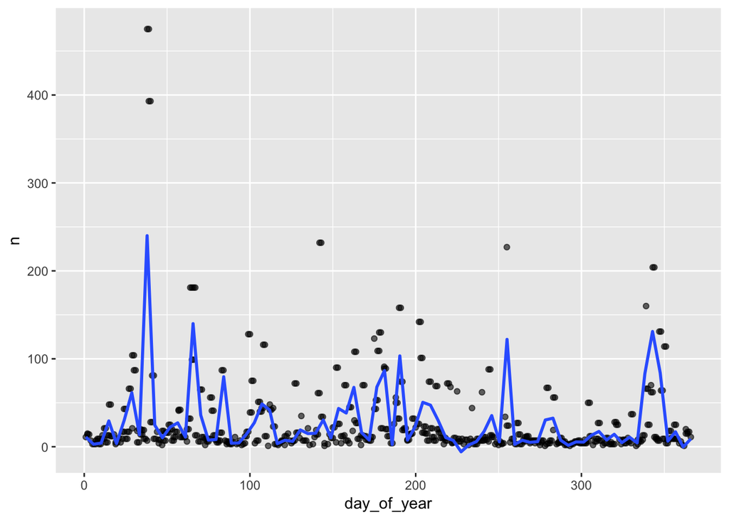

```r
# Create vector of conversions of time_hour to day of the year
doy <- as.numeric(strftime(flights$time_hour, format = "%j"))
# Mutate flights to add day_of_year variable
flights.1 <- flights %>%
  mutate(day_of_year = doy)
# Visualize number of cancelled flights per day
cancelled <- flights.1 %>% filter(is.na(dep_delay) | is.na(arr_delay)) %>%
  add_count(month, day) %>% select(day_of_year, n) %>% distinct()
ggplot(cancelled, aes(x = day_of_year, y = n)) + geom_point(alpha = .6) +
  geom_smooth(span = .01, se = FALSE)
```

4.b. Examination of possible association between average delay and proportion of cancelled flights.

The visualization below suggests that as the average delay increases for a particular day, so does the number of cancelled flights. This makes intuitive sense to anyone with experience flying!

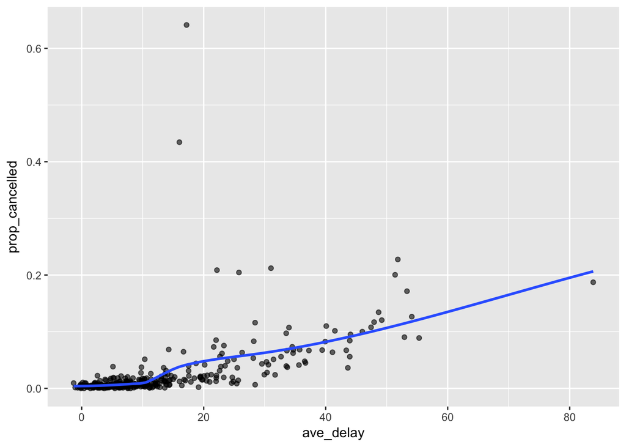

```r
# Compare proportion of cancelled flights to average delay for each day
summary <- flights.1 %>% group_by(day_of_year) %>%
  summarize(
    num_cancelled = sum(is.na(dep_delay) & is.na(arr_delay)),
    prop_cancelled = mean(is.na(dep_delay) & is.na(arr_delay)),
    ave_delay = mean(dep_delay, na.rm = TRUE)
  )
# Visualize comparison of proportion of cancelled flights to average delay
ggplot(summary, aes(x = ave_delay, y = prop_cancelled)) + geom_point(alpha = .6) +
  geom_smooth(se=FALSE)
```

5. I’ve answered this question considering departure delays, not arrival delays. The first data frame below shows that F9 is the carrier with the greatest mean dep_delay. However, the second data frame shows that F9 only flew to one destination (DEN), and only 685 flights. Other carriers made different numbers of flights to different airports, so mean dep_delay is not really comparable between carriers. When I look at the third dataframe, sorted by mean_delay in descending order and grouped by carrier and destination, I can see that EV is the carrier that is most routinely late regardless of destination.

```r
flights %>% group_by(carrier) %>%
  summarize(mean_delay = mean(dep_delay, na.rm = TRUE)) %>%
  arrange(desc(mean_delay))
```

```
## # A tibble: 16 x 2
##    carrier mean_delay
##    <chr>        <dbl>
##  1 F9           20.2
##  2 EV           20.0
##  3 YV           19.0
##  4 FL           18.7
##  5 WN           17.7
##  6 9E           16.7
##  7 B6           13.0
##  8 VX           12.9
##  9 OO           12.6
## 10 UA           12.1
## 11 MQ           10.6
## 12 DL            9.26
## 13 AA            8.59
## 14 AS            5.80
## 15 HA            4.90
## 16 US            3.78
```

```r
flights %>% group_by(carrier, dest) %>% summarize(n())
```

```
## # A tibble: 314 x 3
## # Groups:   carrier [?]
##    carrier dest  `n()`
##    <chr>   <chr> <int>
##  1 9E      ATL      59
##  2 9E      AUS       2
##  3 9E      AVL      10
##  4 9E      BGR       1
##  5 9E      BNA     474
##  6 9E      BOS     914
##  7 9E      BTV       2
##  8 9E      BUF     833
##  9 9E      BWI     856
## 10 9E      CAE       3
## # ... with 304 more rows
```

```r
flights %>% group_by(dest, carrier) %>%
  summarize(
    mean_delay = mean(dep_delay, na.rm = TRUE),
    n = n()) %>%
  arrange(desc(mean_delay)) %>%
  print(n=50)
```

```
## # A tibble: 314 x 4
## # Groups:   dest [105]
##    dest  carrier mean_delay     n
##    <chr> <chr>        <dbl> <int>
##  1 STL   UA            77.5     2
##  2 ORD   OO            67.0     1
##  3 DTW   OO            61.0     2
##  4 RDU   UA            60.0     1
##  5 PBI   EV            48.7     6
##  6 TYS   EV            41.8   323
##  7 CAE   EV            36.7   113
##  8 TUL   EV            34.9   315
##  9 BGR   9E            34.0     1
## 10 MSY   WN            33.4   298
## 11 OKC   EV            30.6   346
```

[output cut: 40 more lines]

6. The sort argument to `count()` sorts the output in descending order of n. It provides a quick way to see not just the max and min, but the several highest and lowest occurring counts. This could give you ideas for next steps in an analysis (e.g. what do the several highest count or several lowest count groups have in common?).

**R for Data Science Exercise 10.5**

1. You can tell an object is a tibble by printing it (it returns the classification “a tibble”), or by using `class()`. You can also tell it’s a tibble when printed in the console, because tibbles are easier to read than data frames (they do not wrap columns around and print them below). They also name the type of data in each column, which data frames do not.
2. The data frame defaults could be frustrating because a typo in subsetting a column name wouldn’t throw an error so you could easily make a mistake without knowing it. Also, it could be frustrating that the type of object being returned changes. When you’re working with a tibble, the results will always also be a tibble, so you don’t have to consider the class of object as you work.

```r
df <- data.frame(abc = 1, xyz = "a")
df$x # Does not distinguish x from xyz, so this code returns the data from column xyz
```

```
## [1] a
## Levels: a
```

```r
tb <- tibble(abc = 1, xyz = "a")
tb$x # Does distinguish x from xyz, so this code returns an error
```

```r
df[, "xyz"] # Returns contents of column xyz as a factor
```

```
## [1] a
## Levels: a
```

```r
tb[, "xyz"] # Returns contents of column xyz as a tibble
```

```
## # A tibble: 1 x 1
##   xyz
##   <chr>
## 1 a
```

```r
df[, c("abc", "xyz")] # Returns a data frame with contents of column xyz as a factor
```

```
##   abc xyz
## 1   1   a
```

```r
tb[, c("abc", "xyz")] # Returns a tibble with contents of column xyz as a character
```

```
## # A tibble: 1 x 2
##     abc xyz
##   <dbl> <chr>
## 1  1.00 a
```

3. You can extract a reference variable named as an object from a tibble as coded here:

```r
vari <- "carrier"
flights[vari]
```

6. The option `n_extra` controls how many additional column names are printed at the footer of a tibble.

**R for Data Science Exercise 12.3.3**

2. The code fails because the column names “1999” and “2000” are non-syntactic and therefore must be surrounded by backticks.
3. Spreading the given tibble fails because “Phillip Woods” has two different values for “age”, presumably because there are two different people in this data set named Phillip Woods. You could solve this problem by adding a new column that distinguishes Phillip Woods #1 from Phillip Woods #2. See code below:

```r
people <- tribble(
  ~name,             ~key,    ~value,
  #-----------------|--------|------
  "Phillip Woods",   "age",       45,
  "Phillip Woods",   "height",   186,
  "Phillip Woods",   "age",       50,
  "Jessica Cordero", "age",       37,
  "Jessica Cordero", "height",   156
)

people %>% mutate(ID = c(1,1,2,1,1)) %>% spread(key, value)
```

```
## # A tibble: 3 x 4
##   name               ID   age height
## * <chr>           <dbl> <dbl>  <dbl>
## 1 Jessica Cordero  1.00  37.0    156
## 2 Phillip Woods    1.00  45.0    186
## 3 Phillip Woods    2.00  50.0     NA
```

4. The variables are pregnant (Y/N), sex (M/F), and some value (probably count). The “sex” variable needs to be gathered:

```r
preg <- tribble(
  ~pregnant, ~male, ~female,
  "yes",     NA,    10,
  "no",      20,    12
)

preg %>% gather("male", "female", key = "sex", value = "n")
```

```
## # A tibble: 4 x 3
##   pregnant sex        n
##   <chr>    <chr>  <dbl>
## 1 yes      male    NA
## 2 no       male    20.0
## 3 yes      female  10.0
## 4 no       female  12.0
```

**R for Data Science Exercise 12.4.3**

1. When `sep` is a character vector, `extra` controls what happens when there are too many pieces and `fill` controls what happens when there aren’t enough pieces to fill out the new columns. See below for examples:

```r
# extra = "warn" (this is the default) gives a warning message and drops extra values
# extra = "drop" does the same thing without a warning
tibble(x = c("a,b,c", "d,e,f,g", "h,i,j")) %>%
  separate(x, c("one", "two", "three"))
```

```
## # A tibble: 3 x 3
##   one   two   three
## * <chr> <chr> <chr>
## 1 a     b     c
## 2 d     e     f
## 3 h     i     j
```

```r
# extra = "merge" only splits at most the number of times as there are new columns and puts whatever is left over into the last column
tibble(x = c("a,b,c", "d,e,f,g", "h,i,j")) %>%
  separate(x, c("one", "two", "three"), extra = "merge")
```

```
## # A tibble: 3 x 3
##   one   two   three
## * <chr> <chr> <chr>
## 1 a     b     c
## 2 d     e     f,g
## 3 h     i     j
```

```r
# fill = "warn" (default) gives a warning and fills with NA from the right
# fill = "right" does the same thing without a warning
tibble(x = c("a,b,c", "d,e", "f,g,i")) %>%
  separate(x, c("one", "two", "three"))
```

```
## # A tibble: 3 x 3
##   one   two   three
## * <chr> <chr> <chr>
## 1 a     b     c
## 2 d     e     <NA>
## 3 f     g     i
```

```r
# fill = "left" fills with NA from the left
tibble(x = c("a,b,c", "d,e", "f,g,i")) %>%
  separate(x, c("one", "two", "three"), fill = "left")
```

```
## # A tibble: 3 x 3
##   one   two   three
## * <chr> <chr> <chr>
## 1 a     b     c
## 2 <NA>  d     e
## 3 f     g     i
```

2. The default for `remove` in `unite()` and `separate()` is TRUE. This removes from the output tibble the original columns that were transformed by the function. You would set it to FALSE if you wanted both the original columns and the transformed ones in your output tibble, as in the example below:

```r
table3 %>%
  separate(rate, into = c("cases", "population"), remove = FALSE)
```

```
## # A tibble: 6 x 5
##   country      year rate              cases  population
## * <chr>       <int> <chr>             <chr>  <chr>
## 1 Afghanistan  1999 745/19987071      745    19987071
## 2 Afghanistan  2000 2666/20595360     2666   20595360
## 3 Brazil       1999 37737/172006362   37737  172006362
## 4 Brazil       2000 80488/174504898   80488  174504898
## 5 China        1999 212258/1272915272 212258 1272915272
## 6 China        2000 213766/1280428583 213766 1280428583
```

**Final Question**

- Download the baby_names.txt file from Canvas.
- Load this file into R correctly and take a glimpse of the output.
- Export this file as an rds file and call it ‘baby_names.rds’.
- Reload the baby_names.rds file and take another glimpse.
- Show all of your code and the output. There should be two data import lines of code, one data export line of code, and two glimpses of the data.

```r
baby_names <- read_delim("baby_names.txt", delim = "|") # Load baby_names.txt
glimpse(baby_names)
```

```
## Observations: 30,000
## Variables: 5
## $ year <int> 1880, 1880, 1880, 1880, 1880, 1880, 1880, 1880, 1880, 188...
## $ sex  <chr> "F", "F", "F", "F", "F", "F", "F", "F", "F", "F", "F", "F...
## $ name <chr> "Mary", "Anna", "Emma", "Elizabeth", "Minnie", "Margaret"...
## $ n    <int> 7065, 2604, 2003, 1939, 1746, 1578, 1472, 1414, 1320, 128...
## $ prop <dbl> 0.072384329, 0.026679234, 0.020521700, 0.019865989, 0.017...
```

```r
saveRDS(baby_names, file = "baby_names.rds") # Export baby_names as rds file

baby_names_rds <- readRDS(file = "baby_names.rds") # Reload baby_names.rds
glimpse(baby_names_rds)
```

```
## Observations: 30,000
## Variables: 5
## $ year <int> 1880, 1880, 1880, 1880, 1880, 1880, 1880, 1880, 1880, 188...
## $ sex  <chr> "F", "F", "F", "F", "F", "F", "F", "F", "F", "F", "F", "F...
## $ name <chr> "Mary", "Anna", "Emma", "Elizabeth", "Minnie", "Margaret"...
## $ n    <int> 7065, 2604, 2003, 1939, 1746, 1578, 1472, 1414, 1320, 128...
## $ prop <dbl> 0.072384329, 0.026679234, 0.020521700, 0.019865989, 0.017...
```